# Power of Social Interaction in NBA

Aadit Patel

5/14/2018

## Introduction

In this tutorial, I will take you through the entire data science pipeline starting from data curation, parsing, and management, exploratory data analysis, and hypothesis testing and machine learning to provide analysis. Throughout this, we will be trying to see if social interaction, influence, and popularity of players and teams have an affect on NBA in terms of game stats and wins.

## Read Dataset and Tidy

The first step will be to include all packages that are necessary and read the multiple datasets that we need. After doing this, we will need to tidy the data set and get rid of any missing data and change names as needed. In order to get a precise and accurate analysis, this step is very important. In this tutorial, we will use multiple datasets provided from kaggle.com under the name of social power nba.

```r
library(broom)
library(tidyverse)
```

```r
library(dplyr)
library(ggplot2)

playerStats <- read.csv(file="/Users/aaditp/Desktop/social-power-nba/nba_2017_players_with_salary_wiki_twitter.csv")
teamAttendance <-  read.csv(file="/Users/aaditp/Desktop/social-power-nba/nba_2017_att_val_elo.csv")

#add twitter stats together to get combined twitter stats.

playerStats$twitterCombined <- playerStats$TWITTER_FAVORITE_COUNT + playerStats$TWITTER_RETWEET_COUNT

head(playerStats, n=10)
```

```
##    X Rk            PLAYER POSITION AGE   MP   FG  FGA   FG. X3P X3PA  X3P.
## 1  0  1 Russell Westbrook       PG  28 34.6 10.2 24.0 0.425 2.5  7.2 0.343
## 2  1  2      James Harden       PG  27 36.4  8.3 18.9 0.440 3.2  9.3 0.347
## 3  2  4     Anthony Davis        C  23 36.1 10.3 20.3 0.505 0.5  1.8 0.299
## 4  3  6  DeMarcus Cousins        C  26 34.2  9.0 19.9 0.452 1.8  5.0 0.361
## 5  4  7    Damian Lillard       PG  26 35.9  8.8 19.8 0.444 2.9  7.7 0.370
## 6  5  8      LeBron James       SF  32 37.8  9.9 18.2 0.548 1.7  4.6 0.363
## 7  6  9     Kawhi Leonard       SF  25 33.4  8.6 17.7 0.485 2.0  5.2 0.380
## 8  7 10     Stephen Curry       PG  28 33.4  8.5 18.3 0.468 4.1 10.0 0.411
## 9  8 11      Kyrie Irving       PG  24 35.1  9.3 19.7 0.473 2.5  6.1 0.401
## 10 9 12      Kevin Durant       SF  28 33.4  8.9 16.5 0.537 1.9  5.0 0.375
##    X2P X2PA  X2P.  eFG.  FT  FTA   FT. ORB DRB  TRB  AST STL BLK TOV  PF
## 1  7.7 16.8 0.459 0.476 8.8 10.4 0.845 1.7 9.0 10.7 10.4 1.6 0.4 5.4 2.3
## 2  5.1  9.6 0.530 0.525 9.2 10.9 0.847 1.2 7.0  8.1 11.2 1.5 0.5 5.7 2.7
## 3  9.7 18.6 0.524 0.518 6.9  8.6 0.802 2.3 9.5 11.8  2.1 1.3 2.2 2.4 2.2
```

[output cut: 40 more lines]

```r
head(teamAttendance, n=10)
```

```
##    X                  TEAM GMS  TOTAL   AVG   PCT VALUE_MILLIONS  ELO CONF
## 1  0         Chicago Bulls  41 888882 21680 103.6           2500 1519 East
## 2  1      Dallas Mavericks  41 811366 19789 103.1           1450 1420 West
## 3  2      Sacramento Kings  41 721928 17608 100.6           1075 1393 West
## 4  3            Miami Heat  41 805400 19643 100.2           1350 1569 East
## 5  4       Toronto Raptors  41 813050 19830 100.2           1125 1600 East
## 6  5  Los Angeles Clippers  41 782609 19088 100.1           2000 1636 West
## 7  6   Cleveland Cavaliers  41 843042 20562 100.0           1200 1545 East
## 8  7 Golden State Warriors  41 803436 19596 100.0           2600 1770 West
## 9  8 Oklahoma City Thunder  41 746323 18203 100.0           1025 1543 West
## 10 9       New York Knicks  41 810741 19774  99.8           3300 1374 East
```

## Analyzing the data

### Does twitter interaction impact indivual player stats and performance?

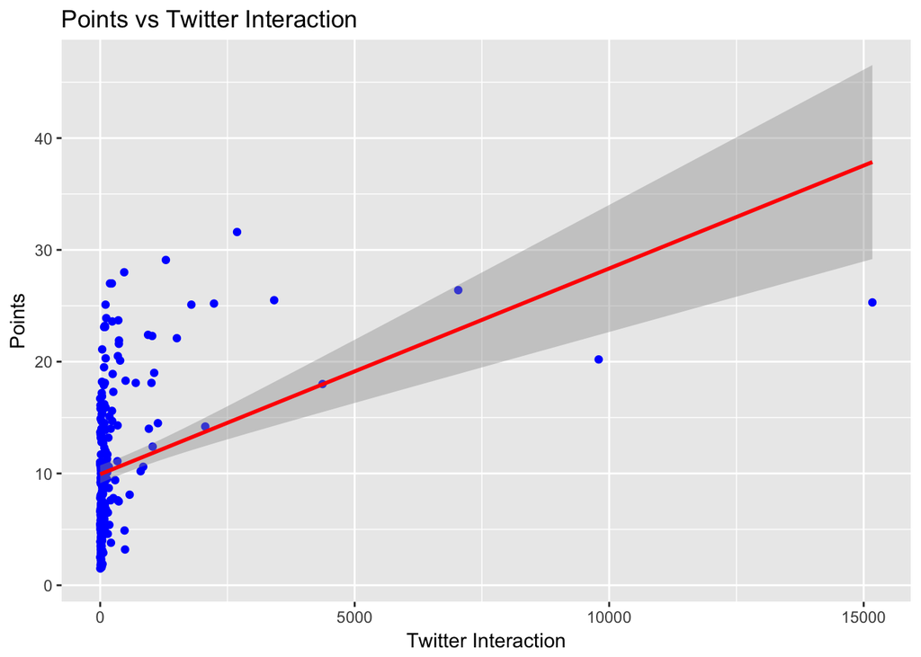

```r
#plot stats against twitter combined stats

#points
ggplot(data = playerStats, aes(x = twitterCombined, y = POINTS) )+
  geom_point(color = "blue") + geom_smooth(method='lm', color = "red") + ggtitle("Points vs Twitter Interaction") +
  xlab("Twitter Interaction") + ylab("Points")
```

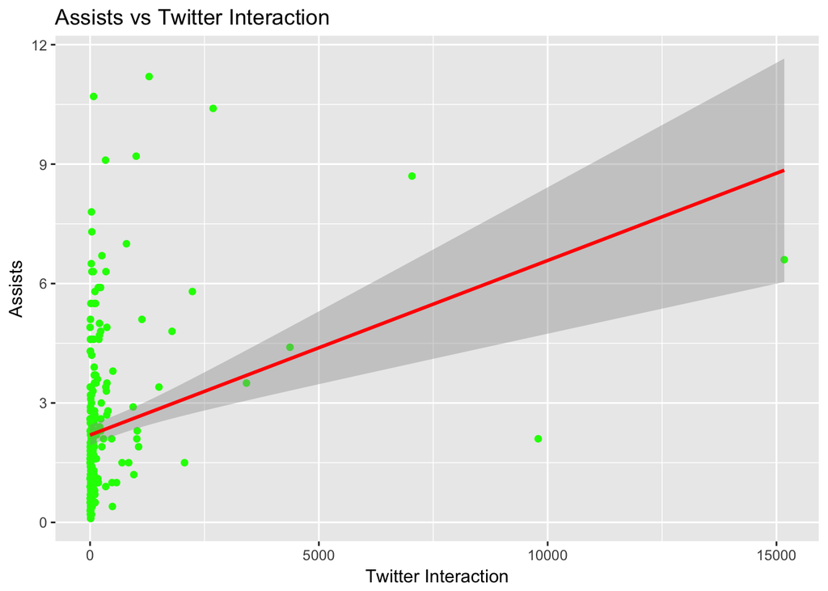

```r
#assists

ggplot(data = playerStats, aes(x = twitterCombined, y = AST) )+
  geom_point(color = "green") + geom_smooth(method='lm', color = "red") + ggtitle("Assists vs Twitter Interaction") +
  xlab("Twitter Interaction") + ylab("Assists")
```

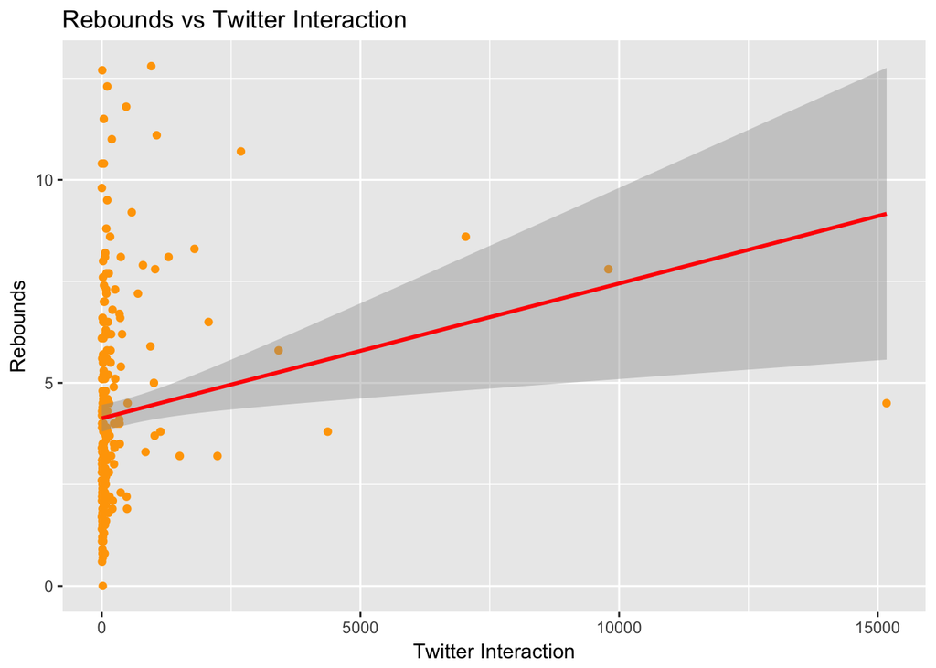

```r
#rebounds
ggplot(data = playerStats, aes(x = twitterCombined, y = TRB) )+
  geom_point(color = "orange") + geom_smooth(method='lm', color = "red") + ggtitle("Rebounds vs Twitter Interaction") +
  xlab("Twitter Interaction") + ylab("Rebounds")
```

As you can see here, twitter stats plotted against player stats give us a positive correlation between the two. For points, assists, and rebounds, there seems to a connection which says that the more a player interacts on twitter, the better their offensive stats are. As you can see from the graphs, there are many outliers that possiblly skew the data. Also since there are many players that do not use social media that much, it can be hard to use this data as fact. Next we will compare offensive and defensive rating with twitter interaction. These ratings may give us a better understanding of how twitter interaction can affect how well an NBA player does.

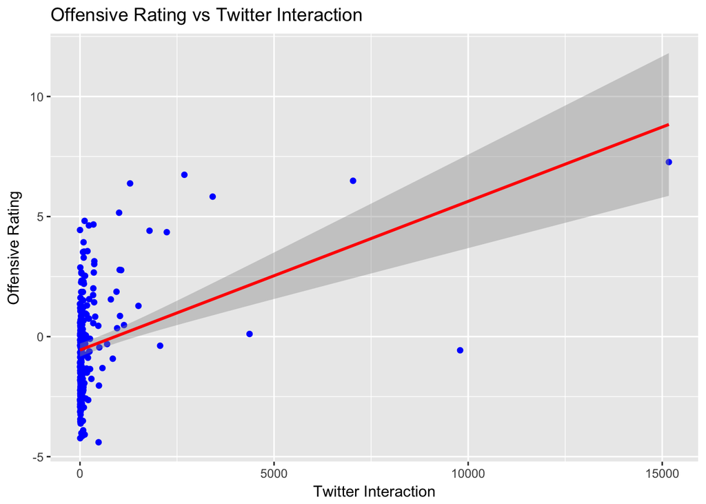

```r
#offensive and defensive ratings plotted against twitter interaction.

#offensive
ggplot(data = playerStats, aes(x = twitterCombined, y = ORPM) )+
  geom_point(color = "blue") + geom_smooth(method='lm', color = "red") + ggtitle("Offensive Rating vs Twitter Interaction") +
  xlab("Twitter Interaction") + ylab("Offensive Rating")
```

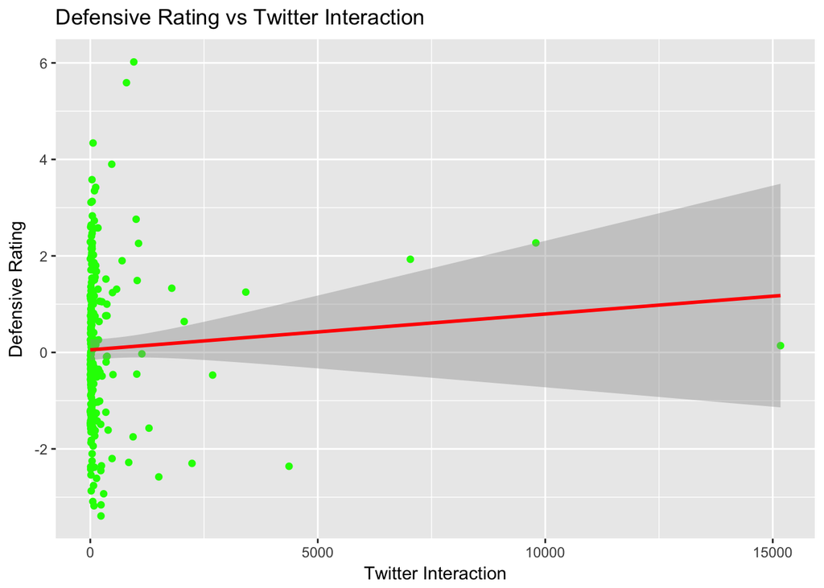

```r
#defensive
ggplot(data = playerStats, aes(x = twitterCombined, y = DRPM) )+
  geom_point(color = "green") + geom_smooth(method='lm', color = "red") + ggtitle("Defensive Rating vs Twitter Interaction") +
  xlab("Twitter Interaction") + ylab("Defensive Rating")
```

As you can see from these graphs, the correlation between Offensive rating and twitter interaction is similar to the correlation of the offensive stats that I tested. Although this is similar to before, the defensive rating tells us a different story. As you can see from the graph, twitter interaction has almost no effect on the defensive rating of an NBA player. From this alone, we can possibly bring up that maybe twitter interaction only has an affect on offensive play and not defensive but due to the outliers, we cannot use this for fact.

### Does fan interaction on affect player stats and performance?

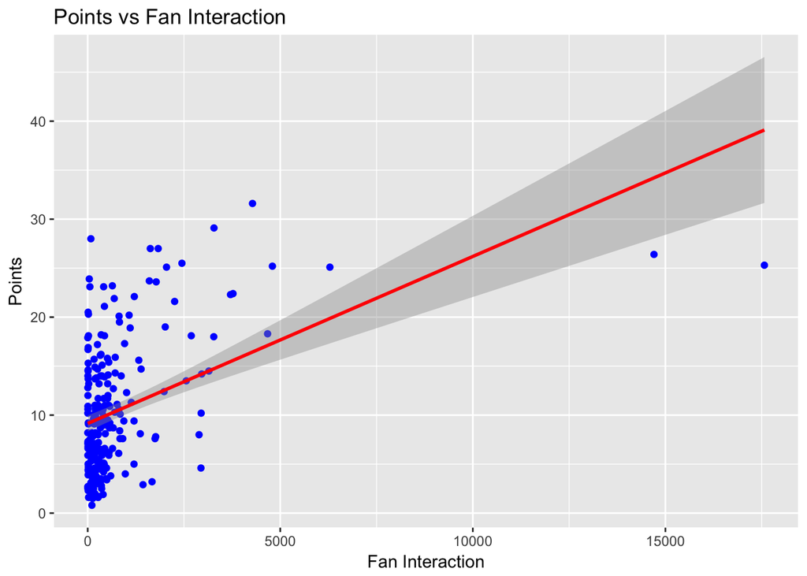

```r
#plot stats against fan interaction


#points
ggplot(data = playerStats, aes(x = PAGEVIEWS, y = POINTS) )+
  geom_point(color = "blue") + geom_smooth(method='lm', color = "red") + ggtitle("Points vs Fan Interaction") +
  xlab("Fan Interaction") + ylab("Points")
```

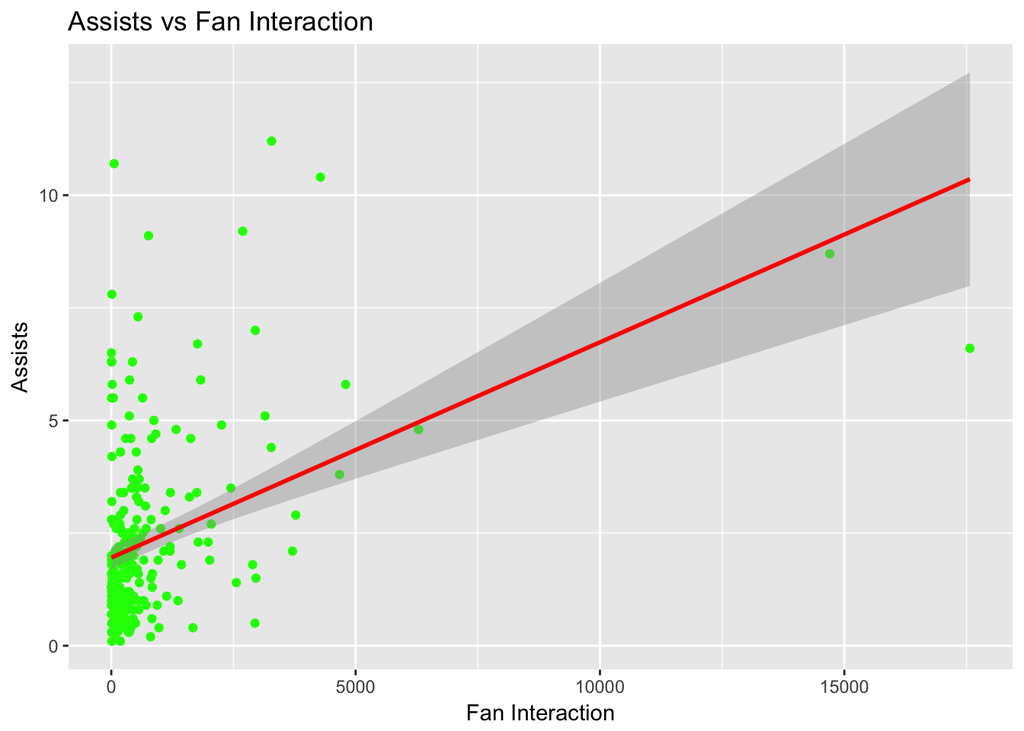

```r
#assists

ggplot(data = playerStats, aes(x = PAGEVIEWS, y = AST) )+
  geom_point(color = "green") + geom_smooth(method='lm', color = "red") + ggtitle("Assists vs Fan Interaction") +
  xlab("Fan Interaction") + ylab("Assists")
```

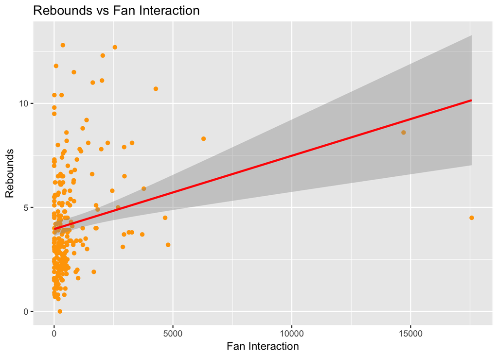

```r
#rebounds
ggplot(data = playerStats, aes(x = PAGEVIEWS, y = TRB) )+
  geom_point(color = "orange") + geom_smooth(method='lm', color = "red") + ggtitle("Rebounds vs Fan Interaction") +
  xlab("Fan Interaction") + ylab("Rebounds")
```

[figure not shown]

```r
#offensive
ggplot(data = playerStats, aes(x = PAGEVIEWS, y = ORPM) )+
  geom_point(color = "blue") + geom_smooth(method='lm', color = "red") + ggtitle("Offensive Rating vs Fan Interaction") +
  xlab("Twitter Interaction") + ylab("Offensive Rating")
```

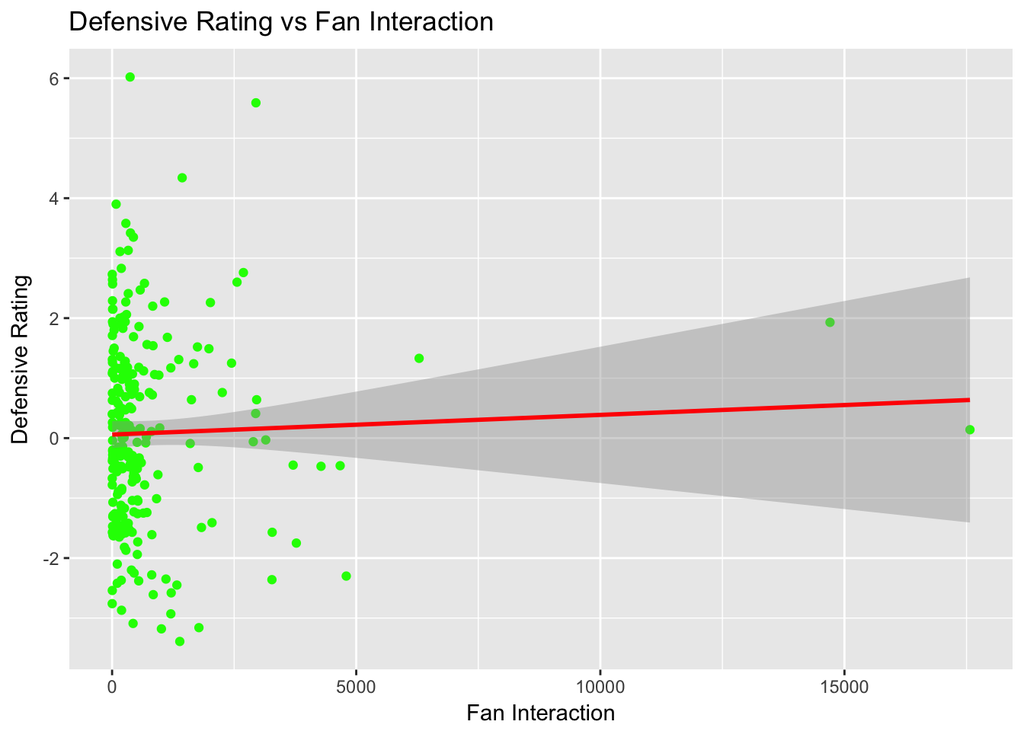

```r
#defensive
ggplot(data = playerStats, aes(x = PAGEVIEWS, y = DRPM) )+
  geom_point(color = "green") + geom_smooth(method='lm', color = "red") + ggtitle("Defensive Rating vs Fan Interaction") +
  xlab("Fan Interaction") + ylab("Defensive Rating")
```

As you can see from these graphs, they are very similar to the twitter interaction graphs and statistics from before. This shows that fan interaction and player interaction have roughly the same impact on player performance in the NBA in terms of stats and rating.

[figure not shown]

```r
playerStats2 <- subset(playerStats, twitterCombined < 2000, PAGEVIEWS < 2000)

ggplot(data = playerStats2, aes(x = twitterCombined, y = ORPM) )+
  geom_point(color = "green") + geom_smooth(method='lm', color = "red") + ggtitle("Offensive Rating vs Fan Interaction") +
  xlab("Twitter Interaction") + ylab("Defensive Rating")
```

[figure not shown]

```r
ggplot(data = playerStats2, aes(x = twitterCombined, y = DRPM) )+
  geom_point(color = "green") + geom_smooth(method='lm', color = "red") + ggtitle("Defensive Rating vs Fan Interaction") +
  xlab("Twitter Interaction") + ylab("Defensive Rating")
```

[figure not shown]

```r
ggplot(data = playerStats2, aes(x = PAGEVIEWS, y = ORPM) )+
  geom_point(color = "green") + geom_smooth(method='lm', color = "red") + ggtitle("Oefensive Rating vs Fan Interaction") +
  xlab("Fan Interaction") + ylab("Defensive Rating")
```

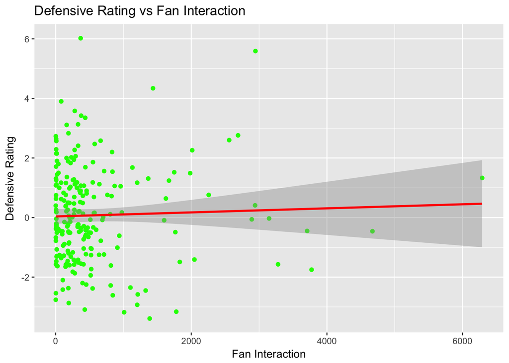

```r
ggplot(data = playerStats2, aes(x = PAGEVIEWS, y = DRPM) )+
  geom_point(color = "green") + geom_smooth(method='lm', color = "red") + ggtitle("Defensive Rating vs Fan Interaction") +
  xlab("Fan Interaction") + ylab("Defensive Rating")
```

Looking at these results, we can say that the correlation that we see between interaction of players and fans against NBA players stats and how well they play is not skewed greatly by the players who are very popular or use twitter a lot. With this we can confirm the accusations made earlier in the tutorial in terms of how interaction impacts player performance.

Now that we know this, lets calculate some statistics for fun.

### What position in basketball is the is the most social and the most popular to fans?

We will now compare the different positions in basketball and see which have the most twitter interaction and which have the most fan interaction.

```r
#lets us see the median and quartile values so we can create a subset.
summary(playerStats$t)
```

```
##    Min. 1st Qu.  Median    Mean 3rd Qu.    Max.    NA's
##     0.0    15.5    40.0   329.3   120.1 15170.0       3
```

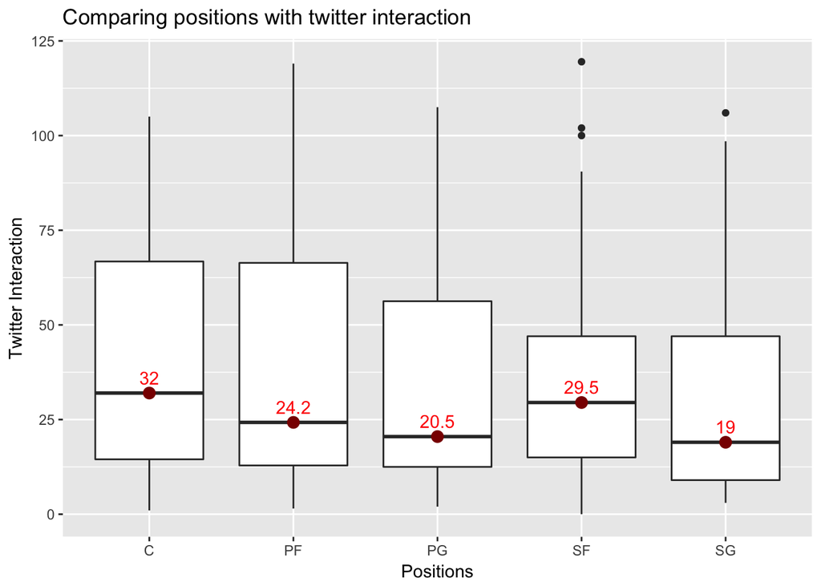

```r
playerStats3rdQuartile <- subset(playerStats, twitterCombined < 120.1, PAGEVIEWS < 642.8)


##twitter interaction
ggplot(data = playerStats3rdQuartile, aes(x=POSITION, y=twitterCombined)) +
 geom_boxplot()+ ggtitle("Comparing positions with twitter interaction") +
  xlab("Positions") + ylab("Twitter Interaction")+ stat_summary(fun.y=median, colour="darkred", geom="point", hape=18, size=3,show_legend = FALSE)+ stat_summary(fun.y=median, colour="red", geom="text", show_legend = FALSE,
               vjust=-0.7, aes( label=round(..y.., digits=1)))
```

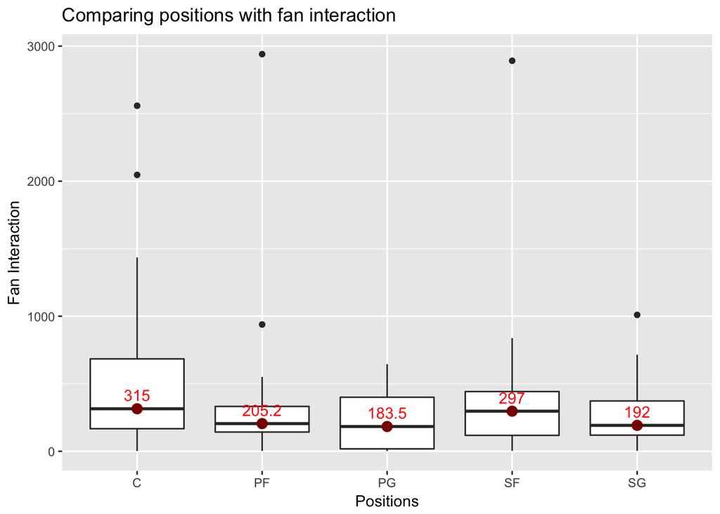

```r
ggplot(data = playerStats3rdQuartile, aes(x=POSITION, y=PAGEVIEWS)) +
 geom_boxplot()+ ggtitle("Comparing positions with fan interaction") +
  xlab("Positions") + ylab("Fan Interaction")+ stat_summary(fun.y=median, colour="darkred", geom="point", hape=18, size=3,show_legend = FALSE)+ stat_summary(fun.y=median, colour="red", geom="text", show_legend = FALSE,
               vjust=-0.7, aes( label=round(..y.., digits=1)))
```

For this I used data that was contained in the 3rd quartile and below for the dataset. I did this because the data beyond that point are is so much greater than the data in the third quartile and below that it did not allow us to see the graph properly and skews the box plot when included. From plotting box plots of each position we learn some interesting information. First we see that the highest when looking at twitter interaction, centers are the most active. I say this because they have the highest median out of all positions for this statistic. Second, I can conclude that the position that has the most fan interaction is center as well. I come to this conclusion the same way as I did with twitter interaction, which is looking at the median. Obviously if I include the last quartile, this data will change but I wanted to see the results for 75% of the data accurately rather than having the top 25% impact the rest of the data so greatly.

### Does fan attendance impact team play?

Now that we have done all these calculation, we have a pretty good understanding of how player and fan social interaction can affect the play and stats of NBA players, lets look at teams. In the followning part of the tutorial, we will look at how fan attendance impacts how well a team performs. To do this, we will look at the team ELO compared to avg attendance and attendance percentage. Team ELO was a statistic given by the kaggle dataset which calculates the relative skill and performance of the team. We will use this to compare team performances and see if there really is a connection between the two variables.

[figure not shown]

```r
ggplot(data = teamAttendance, aes(x = ELO, y = AVG) )+
  geom_point(color = "blue") + geom_smooth(method='lm', color = "red") + ggtitle("Avg attendance vs Team Elo") +
  xlab("Average Attendance") + ylab("Team Elo")+geom_text(aes(label=TEAM),hjust=0, vjust=0)
```

[figure not shown]

```r
ggplot(data = teamAttendance, aes(x = ELO, y = PCT) )+
  geom_point(color = "green") + geom_smooth(method='lm', color = "red") + ggtitle("Percent Attendance vs Team Elo") +
  xlab("Attendance Percent") + ylab("Team Elo")+geom_text(aes(label=TEAM),hjust=0, vjust=0)
```

## Linear Regression Model

```r
twitterRes<-lm(twitterCombined~ORPM + DRPM, data = playerStats)

wikiRes <- lm(PAGEVIEWS~ ORPM + DRPM, data = playerStats)

teamRes<-lm(ELO~AVG, data = teamAttendance)
teamRes<-lm(ELO~PCT, data = teamAttendance)


summary(twitterRes)
```

```
##
## Call:
## lm(formula = twitterCombined ~ ORPM + DRPM, data = playerStats)
##
## Residuals:
##     Min      1Q  Median      3Q     Max
## -1569.6  -427.5  -107.4   179.4 13113.4
##
## Coefficients:
##             Estimate Std. Error t value Pr(>|t|)
## (Intercept)   404.57      81.64   4.956 1.39e-06 ***
## ORPM          226.01      36.39   6.211 2.40e-09 ***
## DRPM           70.99      50.18   1.415    0.158
## ---
## Signif. codes:  0 '***' 0.001 '**' 0.01 '*' 0.05 '.' 0.1 ' ' 1
##
## Residual standard error: 1237 on 233 degrees of freedom
##   (3 observations deleted due to missingness)
## Multiple R-squared:  0.1453, Adjusted R-squared:  0.1379
## F-statistic:  19.8 on 2 and 233 DF,  p-value: 1.144e-08
```

```r
summary(wikiRes)
```

```
##
## Call:
## lm(formula = PAGEVIEWS ~ ORPM + DRPM, data = playerStats)
##
## Residuals:
##     Min      1Q  Median      3Q     Max
## -2717.4  -634.8  -144.5   349.7 14044.4
##
## Coefficients:
##             Estimate Std. Error t value Pr(>|t|)
## (Intercept)   888.75      98.82   8.993  < 2e-16 ***
## ORPM          361.40      43.90   8.232 1.26e-14 ***
## DRPM           70.93      60.79   1.167    0.244
## ---
## Signif. codes:  0 '***' 0.001 '**' 0.01 '*' 0.05 '.' 0.1 ' ' 1
##
## Residual standard error: 1504 on 236 degrees of freedom
## Multiple R-squared:  0.224,  Adjusted R-squared:  0.2174
## F-statistic: 34.06 on 2 and 236 DF,  p-value: 1.007e-13
```

```r
summary(teamRes)
```

```
##
## Call:
## lm(formula = ELO ~ PCT, data = teamAttendance)
##
## Residuals:
##     Min      1Q  Median      3Q     Max
## -165.85  -88.62   14.54   71.33  244.74
##
## Coefficients:
##             Estimate Std. Error t value Pr(>|t|)
## (Intercept) 1212.082    215.152   5.634 4.93e-06 ***
## PCT            3.132      2.292   1.366    0.183
## ---
## Signif. codes:  0 '***' 0.001 '**' 0.01 '*' 0.05 '.' 0.1 ' ' 1
##
## Residual standard error: 105.3 on 28 degrees of freedom
## Multiple R-squared:  0.06249,    Adjusted R-squared:  0.02901
## F-statistic: 1.866 on 1 and 28 DF,  p-value: 0.1828
```